# Cleaning the data

Seth Mottaghinejad  
2017-01-31

In the last section, we proposed ways that we could clean the data. In this section, we actually clean the data. Let's review where we are in the EDA (exploratory data analysis) process:

1. load all the data (and combine them if necessary)
2. inspect the data in preparation cleaning it
3. **clean the data in preparation for analysis**
4. add any interesting features or columns as far as they pertain to the analysis
5. find ways to analyze or summarize the data and report your findings

### Exercises

Run `summary` on the data.

```r
summary(nyc_taxi)
```

```
##  pickup_datetime    dropoff_datetime   passenger_count trip_distance
##  Length:6000000     Length:6000000     Min.   :0.00    Min.   :      0
##  Class :character   Class :character   1st Qu.:1.00    1st Qu.:      1
##  Mode  :character   Mode  :character   Median :1.00    Median :      2
##                                        Mean   :1.66    Mean   :      4
##                                        3rd Qu.:2.00    3rd Qu.:      3
##                                        Max.   :9.00    Max.   :1674368
##
##  pickup_longitude pickup_latitude  rate_code_id dropoff_longitude
##  Min.   :-121.9   Min.   : 0.0    Min.   :1     Min.   :-122
##  1st Qu.: -74.0   1st Qu.:40.7    1st Qu.:1     1st Qu.: -74
##  Median : -74.0   Median :40.8    Median :1     Median : -74
##  Mean   : -72.9   Mean   :40.2    Mean   :1     Mean   : -73
##  3rd Qu.: -74.0   3rd Qu.:40.8    3rd Qu.:1     3rd Qu.: -74
##  Max.   :   0.0   Max.   :57.3    Max.   :6     Max.   :   0
##                                   NA's   :767
##  dropoff_latitude  payment_type   fare_amount         extra
##  Min.   :  0      Min.   :1.00   Min.   :  -450   Min.   :-36
##  1st Qu.: 41      1st Qu.:1.00   1st Qu.:     6   1st Qu.:  0
##  Median : 41      Median :1.00   Median :    10   Median :  0
##  Mean   : 40      Mean   :1.34   Mean   :    13   Mean   :  0
##  3rd Qu.: 41      3rd Qu.:2.00   3rd Qu.:    14   3rd Qu.:  0
##  Max.   :405      Max.   :4.00   Max.   :628545   Max.   :636
##                   NA's   :2
##     mta_tax       tip_amount   tolls_amount improvement_surcharge
##  Min.   :-2.7   Min.   :-64   Min.   :-12   Min.   :-0.30
##  1st Qu.: 0.5   1st Qu.:  0   1st Qu.:  0   1st Qu.: 0.30
##  Median : 0.5   Median :  1   Median :  0   Median : 0.30
##  Mean   : 0.5   Mean   :  2   Mean   :  0   Mean   : 0.30
##  3rd Qu.: 0.5   3rd Qu.:  2   3rd Qu.:  0   3rd Qu.: 0.30
##  Max.   :80.5   Max.   :844   Max.   :906   Max.   : 0.76
##
##   total_amount
##  Min.   :  -451
##  1st Qu.:     9
##  Median :    12
##  Mean   :    16
##  3rd Qu.:    18
##  Max.   :629034
##
```

What are some important things we can tell about the data by looking at the above summary?

Discuss possible ways that some columns may need to be 'cleaned'. By 'cleaned' here we mean - reformatted into the appropriate type, - replaced with another value or an NA, - removed from the data for the purpose of the analysis.

### Solutions

Here are some of the ways we can clean the data:

Some data-cleaning jobs depend on the analysis. For example, turning `payment_type` into a `factor` is unnecessary if we don't intend to use it as a categorical variable in the model. Even so, we might still benefit from turning it into a factor so that we can see counts for it when we run `summary` on the data, or have it show the proper labels when we use it in a plot. Other data- cleaning jobs on the other hand relate to data quality issues. For example, unreasonable bounds for pick-up or drop-off coordinates can be due to error. In such cases, we must decide whether we should clean the data by

- removing rows that have incorrect information for some columns, even though other columns might still be correct
- replace the incorrect information with NAs and decide whether we should impute missing values somehow
- leave the data as is, but think about how doing so could skew some results from our analysis

## Dealing with datetimes

Next we format `pickup_datetime` and `dropoff_datetime` as `datetime` columns. There are different functions for dealing with `datetime` column types, including functions in the `base` package, but we will be using the `lubridate` package for its rich set of functions and simplicity.

```r
library(lubridate)
Sys.setenv(TZ = "US/Pacific") # not important for this dataset, but this is how we set the time zone
```

The function we need is called `ymd_hms`, but before we run it on the data let's test it on a string. Doing so gives us a chance to test the function on a simple input and catch any errors or wrong argument specifications.

```r
ymd_hms("2015-01-25 00:13:08", tz = "US/Eastern") # we can ignore warning message about timezones
```

```
## [1] "2015-01-25 00:13:08 EST"
```

We seem to have the right function and the right set of arguments, so let's now apply it to the data. If we are still unsure about whether things will work, it might be prudent to not immediately overwrite the existing column. We could either write the transformation to a new column or run the transformation on the first few rows of the data and just display the results in the console.

```r
ymd_hms(nyc_taxi$pickup_datetime[1:20], tz = "US/Eastern")
```

```
##  [1] "2016-06-21 21:33:52 EDT" "2016-06-08 09:52:19 EDT"
##  [3] "2016-06-14 23:27:22 EDT" "2016-06-12 20:13:12 EDT"
##  [5] "2016-06-10 23:40:21 EDT" "2016-06-28 16:46:23 EDT"
##  [7] "2016-06-26 14:19:52 EDT" "2016-06-24 05:31:36 EDT"
##  [9] "2016-06-18 12:56:02 EDT" "2016-06-01 20:20:56 EDT"
## [11] "2016-06-14 21:02:39 EDT" "2016-06-08 14:56:59 EDT"
## [13] "2016-06-19 17:11:54 EDT" "2016-06-03 17:15:58 EDT"
## [15] "2016-06-11 04:43:17 EDT" "2016-06-13 12:21:37 EDT"
## [17] "2016-06-30 23:50:48 EDT" "2016-06-15 15:09:48 EDT"
## [19] "2016-06-20 20:34:31 EDT" "2016-06-16 19:06:37 EDT"
```

We now apply the transformation to the whole data and overwrite the original column with it.

```r
nyc_taxi$pickup_datetime <- ymd_hms(nyc_taxi$pickup_datetime, tz = "US/Eastern")
```

There's another way to do the above transformation: by using the `transform` function. Just as was the case with `subset`, `transform` allows us to pass the data as the first argument so that we don't have to prefix the column names with `nyc_taxi$`. The result is a cleaner and more readable notation.

```r
nyc_taxi <- transform(nyc_taxi, dropoff_datetime = ymd_hms(dropoff_datetime, tz = "US/Eastern"))
```

Let's now see some of the benefits of formatting the above columns as `datetime`. The first benefit is that we can now perform date calculations on the data. Say for example that we wanted to know how many data points are in each week. We can use `table` to get the counts and the `week` function in `lubridate` to extract the week (from 1 to 52 for a non-leap year) from `pickup_datetime`.

```r
table(week(nyc_taxi$pickup_datetime)) # `week`
```

```
##
##      1      2      3      4      5      6      7      8      9     10
## 214051 243272 246876 184836 239827 241759 245821 243568 239014 227594
##     11     12     13     14     15     16     17     18     19     20
## 229391 227115 216875 236555 238668 234649 219985 236080 232334 237423
##     21     22     23     24     25     26
## 229126 203470 240475 234064 229246 227925
```

```r
table(week(nyc_taxi$pickup_datetime), month(nyc_taxi$pickup_datetime)) # `week` and `month` are datetime functions
```

```
##
##           1      2      3      4      5      6
##   1  214051      0      0      0      0      0
##   2  243272      0      0      0      0      0
##   3  246876      0      0      0      0      0
##   4  184836      0      0      0      0      0
##   5  110965 128862      0      0      0      0
##   6       0 241759      0      0      0      0
##   7       0 245821      0      0      0      0
##   8       0 243568      0      0      0      0
##   9       0 139990  99024      0      0      0
##   10      0      0 227594      0      0      0
##   11      0      0 229391      0      0      0
##   12      0      0 227115      0      0      0
##   13      0      0 216875      0      0      0
##   14      0      0      0 236555      0      0
##   15      0      0      0 238668      0      0
##   16      0      0      0 234649      0      0
##   17      0      0      0 219985      0      0
##   18      0      0      0  70143 165937      0
##   19      0      0      0      0 232334      0
##   20      0      0      0      0 237423      0
##   21      0      0      0      0 229126      0
##   22      0      0      0      0 135180  68290
##   23      0      0      0      0      0 240475
##   24      0      0      0      0      0 234064
##   25      0      0      0      0      0 229246
##   26      0      0      0      0      0 227925
```

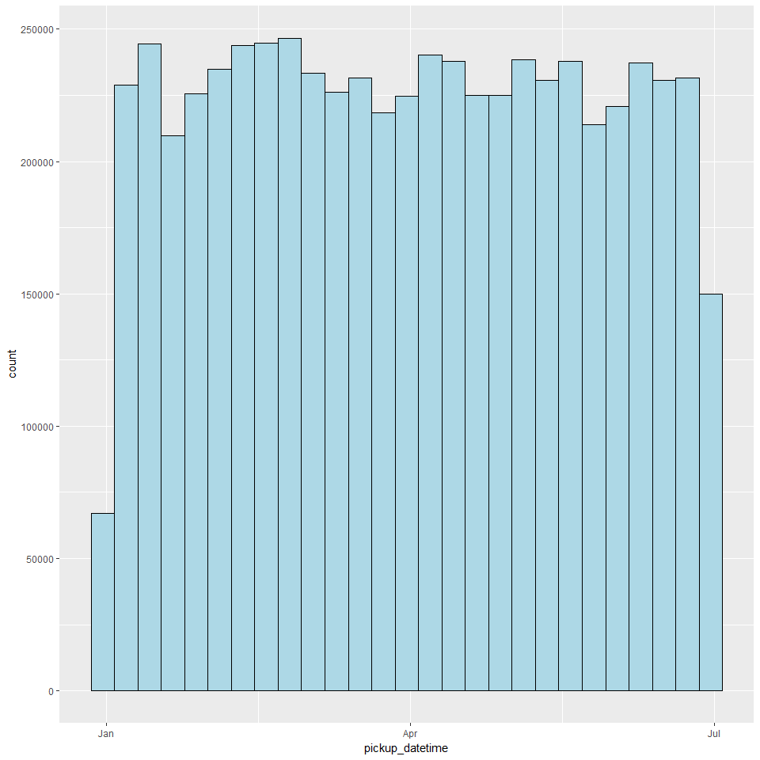

```r
library(ggplot2)
ggplot(data = nyc_taxi) +
  geom_histogram(aes(x = pickup_datetime), col = "black", fill = "lightblue",
  binwidth = 60*60*24*7) # the bin has a width of one week
```

Notice how the x-axis is properly formatted as a date without any manual input from us. Both the summary and the plot above would not have been possible if `pickup_datetime` was still a character column.

## Dealing with factors

It's time to turn our attention to the categorical columns in the dataset. Ideally, categorical columns should be turned into `factor` (usually from `character` or `integer`). A `factor` is the appropriate data type for a categorical column. When we loaded the data in R using `read.csv`, we set `stringsAsFactors = FALSE` to prevent any `character` columns from being turned into a factor. This is generally a good idea, because some character columns (such as columns with raw text in them or alpha-numeric ID columns) are not appropriate for factors. Accidentally turning such columns into factors can result in overhead, especially when data sizes are large. The overhead is the result of R having to keep a tally of all the factor levels. We do not have any `character` columns in this dataset that need to be converted to factors, but we have `integer` columns that represent categorical data. These are the columns with low cardinality, as can be seen here:

```r
sapply(nyc_taxi, num.distinct)
```

```
##       pickup_datetime      dropoff_datetime       passenger_count
##               4819099               4818760                    10
##         trip_distance      pickup_longitude       pickup_latitude
##                  4035                 31159                 56804
##          rate_code_id     dropoff_longitude      dropoff_latitude
##                     7                 47211                 80240
##          payment_type           fare_amount                 extra
##                     5                  1524                    40
##               mta_tax            tip_amount          tolls_amount
##                    15                  3100                   716
## improvement_surcharge          total_amount
##                     8                  9541
```

Fortunately, the site that hosted the dataset also provides us with a [data dictionary](http://www.nyc.gov/html/tlc/downloads/pdf/data_dictionary_trip_records_y%20ellow.pdf). Going over the document helps answer what the categorical columns are and what each category represents.

For example, for `rate_code_id`, the mapping is as follows:

- 1 = Standard rate
- 2 = JFK
- 3 = Newark
- 4 = Nassau or Westchester
- 5 = Negotiated fare
- 6 = Group ride

The above information helps us properly label the factor levels.

Notice how `summary` shows us numeric summaries for the categorical columns right now.

```r
summary(nyc_taxi[ , c('rate_code_id', 'payment_type')]) # shows numeric summaries for both columns
```

```
##   rate_code_id  payment_type
##  Min.   :1     Min.   :1.00
##  1st Qu.:1     1st Qu.:1.00
##  Median :1     Median :1.00
##  Mean   :1     Mean   :1.34
##  3rd Qu.:1     3rd Qu.:2.00
##  Max.   :6     Max.   :4.00
##  NA's   :767   NA's   :2
```

A quick glance at `payment_type` shows two payments as by far the most common. The data dictionary confirms for us that they correspond to card and cash payments.

```r
table(nyc_taxi$payment_type)
```

```
##
##       1       2       3       4
## 3982658 1986124   23153    8063
```

```r
nyc_taxi <- transform(nyc_taxi,
rate_code_id = factor(rate_code_id,
levels = 1:6, labels = c('standard', 'JFK', 'Newark', 'Nassau or Westchester', 'negotiated', 'group ride')),
payment_type = factor(payment_type,
levels = 1:2, labels = c('card', 'cash')
))
```

```r
head(nyc_taxi[ , c('rate_code_id', 'payment_type')]) # now proper labels are showing in the data
```

```
##   rate_code_id payment_type
## 1     standard         card
## 2     standard         cash
## 3     standard         card
## 4     standard         card
## 5     standard         card
## 6     standard         cash
```

```r
summary(nyc_taxi[ , c('rate_code_id', 'payment_type')]) # now counts are showing in the summary
```

```
##                 rate_code_id     payment_type
##  standard             :5839179   card:3982658
##  JFK                  : 128092   cash:1986124
##  Newark               :  10939   NA's:  31218
##  Nassau or Westchester:   2716
##  negotiated           :  18253
##  group ride           :     54
##  NA's                 :    767
```

It is very important that the `labels` be in the same order as the `levels` they map into.

What about `passenger_count`? should it be treated as a `factor` or left as integer? The answer is it depends on how it will be used, especially in the context of modeling. Most of the time, such a column is best left as `integer` in the data and converted into factor 'on-the-fly' when need be (such as when we want to see counts, or when we want a model to treat the column as a `factor`).

Our data-cleaning is for now done. We are ready to now add new features to the data, but before we do so, let's briefly revisit what we have so far done from the beginning, and see if we could have taken any shortcuts. That is the subject of the next chapter.